# Model Recovery Heuristics

Markus Steiner

17 7 2018

In the model recovery we simulated data of 50 participants x 3 environments for a total of 7 models. The seven models, together with a short description can be found in the Table below. These data were then used to recover the parameters. Here is a table of the percent correct recoveries:

Fitted models with description

[output not shown]

Let’s first look at the model fitting results of the actual choice data from the experiment.

Proportion of persons per condition that are best described by a certain model.

|  | Goal | NoGoal |
| --- | --- | --- |
| GoalHeur | 0.302 | 0.290 |
| NaturalMean | 0.095 | 0.176 |
| Random | 0.053 | 0.045 |
| RL | 0.286 | 0.353 |
| RLGoal | 0.005 | 0.000 |
| SampEx_Heur_Goal | 0.026 | 0.045 |
| ThreshHeur | 0.233 | 0.090 |

This results show that the models that incorporate a goal are better in fitting participants from the goal condition. However, the evidence is not very strong in the sense that around 40% of participants from the goal condition are best classified by a model that does not incorporate a goal.

Let’s see how this looks if we split the table in the three different conditions.

Low Condition:

|  | Goal | NoGoal |
| --- | --- | --- |
| GoalHeur | 0.348 | 0.377 |
| NaturalMean | 0.121 | 0.217 |
| Random | 0.015 | 0.014 |
| RL | 0.333 | 0.304 |
| RLGoal | 0.015 | 0.000 |
| SampEx_Heur_Goal | 0.045 | 0.014 |
| ThreshHeur | 0.121 | 0.072 |

Equal Condition:

|  | Goal | NoGoal |
| --- | --- | --- |
| GoalHeur | 0.387 | 0.333 |
| NaturalMean | 0.065 | 0.173 |
| Random | 0.048 | 0.000 |
| RL | 0.194 | 0.373 |
| SampEx_Heur_Goal | 0.032 | 0.040 |
| ThreshHeur | 0.274 | 0.080 |

High Condition:

|  | Goal | NoGoal |
| --- | --- | --- |
| GoalHeur | 0.164 | 0.169 |
| NaturalMean | 0.098 | 0.143 |
| Random | 0.098 | 0.117 |
| RL | 0.328 | 0.377 |
| SampEx_Heur_Goal | 0.000 | 0.078 |
| ThreshHeur | 0.311 | 0.117 |

Here’s an overview of the models and the fitted parameter values separated for conditions.

| model_best | variance.condition | goal.condition | bic_mean | bic_sd | par_Imp_mean | par_Imp_sd | par_Choice_mean | par_Choice_sd | N |
| --- | --- | --- | --- | --- | --- | --- | --- | --- | --- |
| GoalHeur | Equal | Goal | 271.4823 | 54.776403 | NA | NA | 0.7400612 | 0.1408684 | 24 |
| GoalHeur | Equal | NoGoal | 282.8797 | 65.645782 | NA | NA | 0.7246948 | 0.1239450 | 25 |
| GoalHeur | High | Goal | 319.5649 | 17.102917 | NA | NA | 0.6757430 | 0.0481719 | 10 |
| GoalHeur | High | NoGoal | 296.9778 | 54.443170 | NA | NA | 0.6911930 | 0.1330120 | 13 |
| GoalHeur | Low | Goal | 264.5126 | 66.899723 | NA | NA | 0.7655701 | 0.1088817 | 23 |
| GoalHeur | Low | NoGoal | 263.8646 | 64.991647 | NA | NA | 0.7705875 | 0.0996128 | 26 |
| NaturalMean | Equal | Goal | 289.2000 | 61.613222 | NA | NA | 0.0895788 | 0.0561029 | 4 |
| NaturalMean | Equal | NoGoal | 278.8815 | 58.548664 | NA | NA | 0.0970740 | 0.0605210 | 13 |
| NaturalMean | High | Goal | 310.1997 | 25.611868 | NA | NA | 0.0672034 | 0.0269117 | 6 |
| NaturalMean | High | NoGoal | 272.4381 | 57.905698 | NA | NA | 0.1261462 | 0.0758268 | 11 |
| NaturalMean | Low | Goal | 296.1140 | 39.448430 | NA | NA | 0.0843941 | 0.0294413 | 8 |
| NaturalMean | Low | NoGoal | 260.1856 | 75.048260 | NA | NA | 0.1255262 | 0.0839724 | 15 |
| Random | Equal | Goal | 346.5740 | 0.000000 | NA | NA | NA | NA | 3 |
| Random | High | Goal | 346.5740 | 0.000000 | NA | NA | NA | NA | 6 |
| Random | High | NoGoal | 346.5740 | 0.000000 | NA | NA | NA | NA | 9 |
| Random | Low | Goal | 346.5740 | NA | NA | NA | NA | NA | 1 |
| Random | Low | NoGoal | 346.5740 | NA | NA | NA | NA | NA | 1 |
| RL | Equal | Goal | 267.6467 | 49.254678 | 0.6272985 | 0.2770348 | 0.0967416 | 0.0775990 | 12 |
| RL | Equal | NoGoal | 268.5119 | 60.984799 | 0.6871591 | 0.2741437 | 0.1015204 | 0.1318935 | 28 |
| RL | High | Goal | 298.3732 | 34.186653 | 0.7709885 | 0.2574123 | 0.0572224 | 0.0364561 | 20 |
| RL | High | NoGoal | 269.8952 | 54.000839 | 0.7624442 | 0.2421834 | 0.0829347 | 0.0709796 | 29 |
| RL | Low | Goal | 280.9313 | 55.537556 | 0.7748554 | 0.2203979 | 0.0823405 | 0.1113191 | 22 |
| RL | Low | NoGoal | 234.3237 | 88.445313 | 0.6781546 | 0.2960836 | 0.1583503 | 0.2050403 | 21 |
| RLGoal | Low | Goal | 251.3520 | NA | 0.0826872 | NA | 0.2076746 | NA | 1 |
| SampEx_Heur_Goal | Equal | Goal | 336.7290 | 4.464672 | 6.5000000 | 7.7781746 | 0.1020844 | 0.1000132 | 2 |
| SampEx_Heur_Goal | Equal | NoGoal | 333.0930 | 5.382035 | 1.6666667 | 0.5773503 | 0.0396457 | 0.0177938 | 3 |
| SampEx_Heur_Goal | High | NoGoal | 327.4885 | 25.849641 | 3.0000000 | 2.2803509 | 0.0661601 | 0.0374209 | 6 |
| SampEx_Heur_Goal | Low | Goal | 319.9547 | 17.180266 | 1.3333333 | 0.5773503 | 0.0434889 | 0.0075401 | 3 |
| SampEx_Heur_Goal | Low | NoGoal | 332.7940 | NA | 1.0000000 | NA | 0.0292771 | NA | 1 |
| ThreshHeur | Equal | Goal | 289.1208 | 45.478433 | 7.4601956 | 6.6583076 | 0.6546033 | 0.2159525 | 17 |
| ThreshHeur | Equal | NoGoal | 279.7033 | 58.260508 | 7.9819875 | 7.1457799 | 0.4010392 | 0.3022149 | 6 |
| ThreshHeur | High | Goal | 279.4897 | 53.503947 | 2.1838823 | 2.9892058 | 0.7151558 | 0.1825927 | 19 |
| ThreshHeur | High | NoGoal | 264.5966 | 62.925298 | 10.3332356 | 7.8422403 | 0.3209748 | 0.2520169 | 9 |
| ThreshHeur | Low | Goal | 306.3809 | 31.720108 | 8.6271451 | 8.4663269 | 0.6315544 | 0.2205022 | 8 |
| ThreshHeur | Low | NoGoal | 283.7132 | 43.516427 | 16.1800776 | 6.9146166 | 0.6282599 | 0.2677810 | 5 |

## Model Recovery

So far so good. Now let’s check whether with the new models the model recovery was more successfull. Below is a table with the proportion of recoveries. It shows that the models were all relatively well recovered, with a correct recovery rate of over $.94$.

|  | GoalHeur | NaturalMean | Random | RL | RLGoal | SampEx_Heur_Goal | ThreshHeur |
| --- | --- | --- | --- | --- | --- | --- | --- |
| GoalHeur | 0.96 | 0.01 | 0.03 | 0.01 | 0 | 0.00 | 0.00 |
| NaturalMean | 0.01 | 0.99 | 0.00 | 0.00 | 0 | 0.00 | 0.00 |
| Random | 0.01 | 0.01 | 0.98 | 0.00 | 0 | 0.00 | 0.01 |
| RL | 0.01 | 0.01 | 0.00 | 0.98 | 0 | 0.00 | 0.00 |
| RLGoal | 0.00 | 0.00 | 0.00 | 0.00 | 1 | 0.00 | 0.00 |
| SampEx_Heur_Goal | 0.00 | 0.00 | 0.01 | 0.00 | 0 | 0.99 | 0.00 |
| ThreshHeur | 0.01 | 0.00 | 0.05 | 0.00 | 0 | 0.00 | 0.94 |

Now let’s look at some plots of true and recovered parameters for the different models.

### Reinforcement Learning model

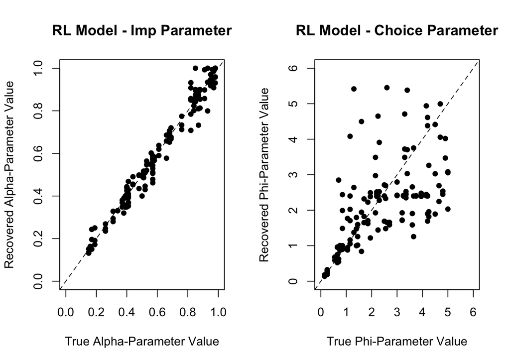

### RLGoal Model

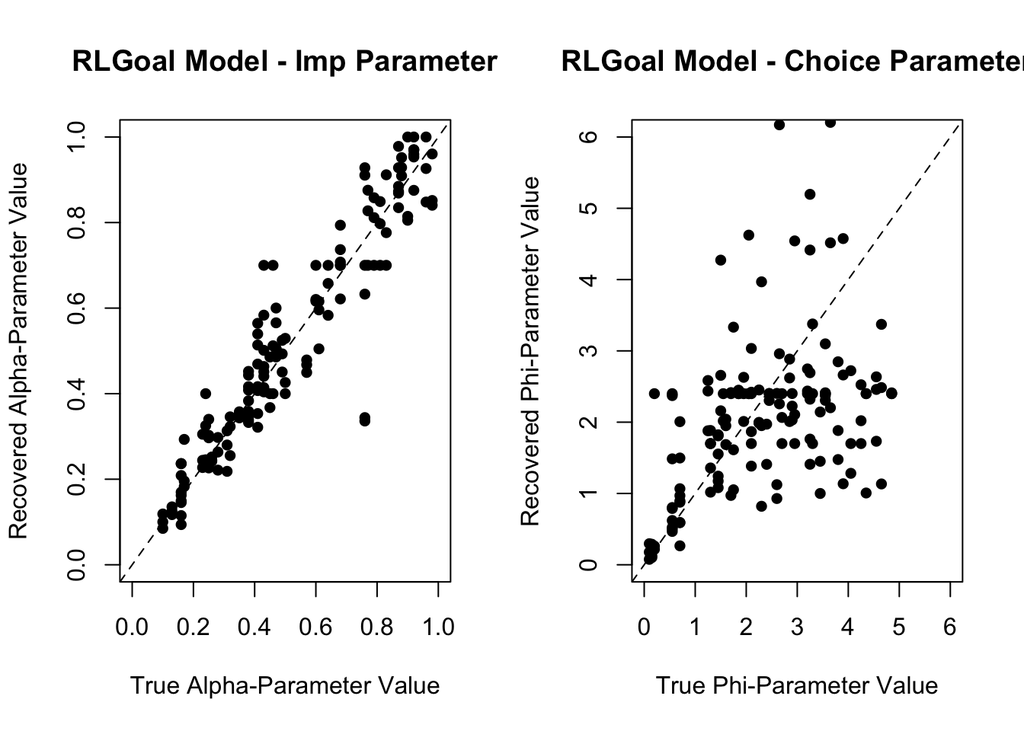

### GoalHeur Model

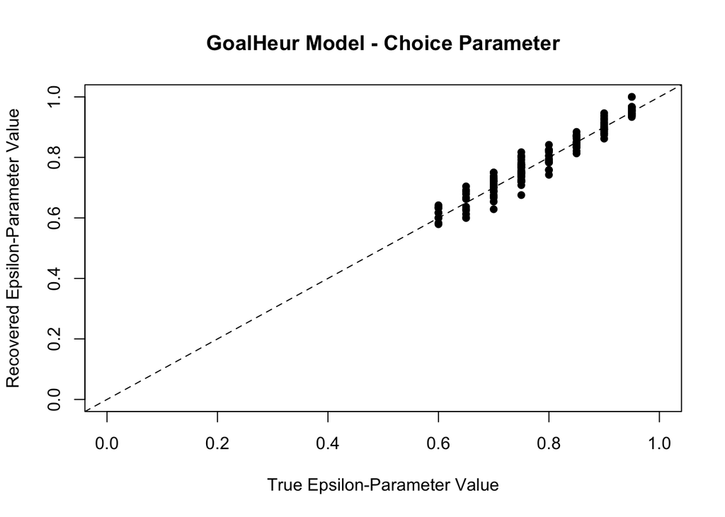

### ThreshHeur Model

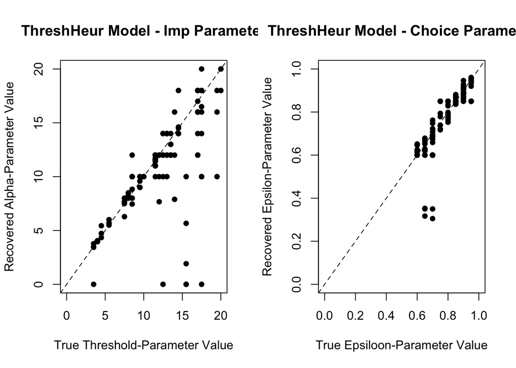

### SampEx Heur Model

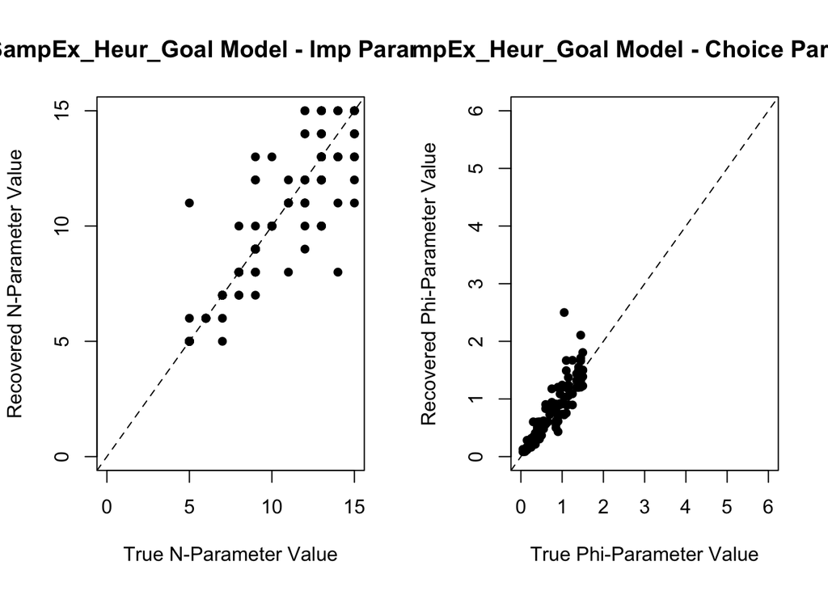

### Natural Mean model

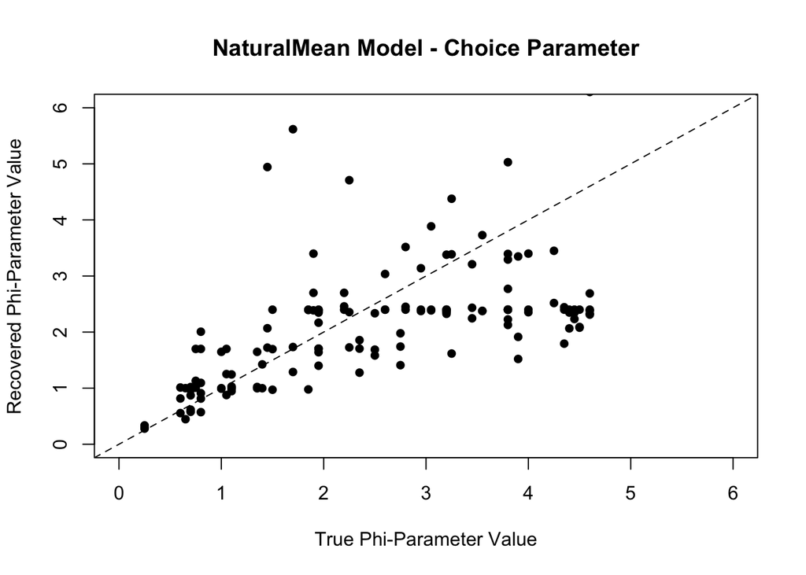